# Midterm Project

Author

Carissa Feliciano

# Introduction

The Surveillance, Epidemiology, and End Results (SEER) program of the National Cancer Institute (NCI) collects cancer incidence and survival data from population-based cancer registries across the US. The SEER database includes information on patient demographics, primary tumor site, tumor morphology, stage at diagnosis, first course of treatment, and vital statistics. The SEER Research Plus and NCCR Database includes data from 1975-2021.

Lung cancer is the leading cause of cancer deaths for both men and women in the US, with non-small cell lung cancer (NSCLC) accounting for 80-85% of cases (1). Lung cancer in young adults, defined here as age ≤50 years, is relatively rare. From 2014-2018, 7.2% of incident lung cancer cases were in adults less than 55 years of age (2). Studies have suggested that young patients with non-small cell lung cancer have different clinical and pathologic characteristics compared to older patients, such as a higher proportion of adenocarcinoma, higher prevalence of targetable driver mutations, and better prognosis (3,4). While several studies have investigated racial/ethnic disparities among all lung cancer patients, there is limited data characterizing racial/ethnic disparities among young NSCLC patients (aged ≤50 years (5).

The primary questions of interest: Is survival time associated with race/ethnicity among young adults (age 18-50) with non-small cell lung cancer (NSCLC)? If so, can differences in the frequency distributions of sex, histologic subtype, and stage at diagnosis explain any differences in survival across the racial/ethnic groups?

# Methods

## Data Extraction and Data Wrangling

The data was extracted from the SEER-17 database, which covers approximately 26.5% of the US population (6). The SEER Stat program was used to access the SEER-17 database. The SEER Stat program was used to filter for cases that met the following criteria: incident diagnosis of non-small cell lung cancer between January 1, 2011 and December 31, 2021, aged 18 to 50 years at the time of diagnosis, first primary malignancy, and residence in California. Cases of non-small cell lung cancer (NSCLC) were identified using primary site codes and histology ICD-O-3 codes, as described by Hansen et al. and Ganti et al., respectively (7, 8). The primary site codes were C34.0 (Main bronchus), C34.1 (Upper lobe, lung), C34.2 (Middle lobe, lung), C34.3 (Lower lobe, lung), C34.8 (Overlapping lesion of lung), and C34.9 (Lung, NOS). The histology ICD-O-3 codes are listed below.

Histology ICD-O-3 codes included by category:  
- Squamous cell carcinoma: 8051–8052, 8070-8076, 8078, 8083-8084, 8090, 8094, 8123  
- Adenocarcinoma: 8015, 8050, 8140-8141, 8143-8145, 8147, 8190, 8201, 8211, 8250-8255, 8260, 8290, 8310, 8320, 8323, 8333, 8401, 8440, 8470-8471, 8480-8481, 8490, 8503, 8507, 8550, 8570-8572, 8574, 8576  
- Large cell carcinoma: 8012–8014, 8021, 8034, 8082  
- Not otherwise specified: 8046, 8003–8004, 8022, 8030, 8031-8033, 8035, 8120, 8200, 8240–8241, 8243–8246, 8249, 8430, 8525, 8560, 8562, 8575

Using the SEER Stat program, 40 variables were extracted, including demographics, staging, treatment, and survival. The resulting dataset was exported from the SEER Stat program as a csv file and then uploaded into R. Once in R, six variables relevant to the primary question were selected: “Age recode with single ages and 90+”, “Sex”, “Race and origin recode (NHW, NHB, NHAIAN, NHAPI, Hispanic)”, “Histologic Type ICD-O-3”, “Combined Summary Stage (2004+)”, and “Survival months”.

The key variables were renamed to streamline coding. The survival months, age, and ICD-O-3 variables were converted from characters to integers. Prior to converting the age variable, the text “years” was removed from each value. The “race and origin” variable was converted from characters to factors.

A new variable called “Histology” was created to group the histologies based on ICD-O-3 codes into the following four categories: Squamous cell carcinoma, Adenocarcinoma, Large cell carcinoma, and Not otherwise specified. The ICD-O-3 codes were grouped based on the categories cited by Ganti et al (8). To ensure the variable was correctly coded, a summary table was created that contained the total number of observations per ICD code grouped by histology.

```r
library(dplyr)
library(ggplot2)
library(RColorBrewer)
library(kableExtra)
library(DT)
```

```r
seer <- data.table::fread(file.path("~", "Downloads", "Young_NSCLC_California_Firstprimary_2011-2021_FINAL.csv"))
```

```r
#Select only the relevant variables
seer <- seer |>
  select(`Age recode with single ages and 90+`, `Sex`, `Race and origin recode (NHW, NHB, NHAIAN, NHAPI, Hispanic)`, `Histologic Type ICD-O-3`, `Combined Summary Stage (2004+)`, `Survival months`)
```

```r
# Rename variables
seer <- seer |>
  rename(
    race = `Race and origin recode (NHW, NHB, NHAIAN, NHAPI, Hispanic)`,
    survival = `Survival months`,
    age = `Age recode with single ages and 90+`,
    sex = `Sex`,
    ICD = `Histologic Type ICD-O-3`,
    stage = `Combined Summary Stage (2004+)`
  )

# Convert variables to integers or factors
seer$race <- as.factor(seer$race)

seer$survival <- as.integer(seer$survival)
seer$age <- gsub(" years", "", seer$age)
seer$age <- as.integer(seer$age)

seer$sex <- as.factor(seer$sex)

seer$ICD <- as.integer(seer$ICD)

seer$stage <- as.factor(seer$stage)
```

```r
# Create a new categorical variable named "Histology" based on ICD-0-3 codes with 4 categories (Squamous cell carcinoma, Adenocarcinoma, Large cell carcinoma, and Not otherwise specified)

seer <- seer |>
  mutate(
    histology = case_when(
      ICD %in% c(8051, 8052, 8070:8076, 8078, 8083, 8084, 8090, 8094, 8123) ~ "Squamous Cell Carcinoma",
      ICD %in% c(8015, 8050, 8140, 8141, 8143:8145, 8147, 8190, 8201, 8211, 8250:
8255, 8260, 8290, 8310, 8320, 8323, 8333, 8401, 8440, 8470, 8471,
8480, 8481, 8490, 8503, 8507, 8550, 8570:8572, 8574, 8576) ~ "Adenocarcinoma",
      ICD %in% c(8012:8014, 8021, 8034, 8082) ~ "Large Cell Carcinoma",
      TRUE ~ "Not Otherwise Specified"
    ))

seer$histology <- as.factor(seer$histology)
```

```r
# Create summary table to ensure "histology" variable was correctly coded

histology_icd_count <- seer |>
  group_by(histology, ICD) |>
  summarise(
    count = n(),
    .groups = "keep"
    )

kable(histology_icd_count) |>
  kable_styling(bootstrap_options = "striped", full_width = FALSE) |>
  scroll_box(height = "200px")
```

| histology | ICD | count |
| --- | --- | --- |
| Adenocarcinoma | 8050 | 1 |
| Adenocarcinoma | 8140 | 2645 |
| Adenocarcinoma | 8250 | 34 |
| Adenocarcinoma | 8252 | 2 |
| Adenocarcinoma | 8253 | 28 |
| Adenocarcinoma | 8254 | 4 |
| Adenocarcinoma | 8255 | 70 |
| Adenocarcinoma | 8260 | 46 |
| Adenocarcinoma | 8310 | 3 |
| Adenocarcinoma | 8323 | 3 |
| Adenocarcinoma | 8333 | 4 |
| Adenocarcinoma | 8480 | 112 |
| Adenocarcinoma | 8481 | 20 |
| Adenocarcinoma | 8490 | 22 |
| Adenocarcinoma | 8507 | 6 |
| Adenocarcinoma | 8550 | 54 |
| Adenocarcinoma | 8574 | 3 |
| Adenocarcinoma | 8576 | 2 |
| Large Cell Carcinoma | 8012 | 22 |
| Large Cell Carcinoma | 8013 | 36 |
| Large Cell Carcinoma | 8014 | 1 |
| Large Cell Carcinoma | 8082 | 3 |
| Not Otherwise Specified | 8022 | 9 |
| Not Otherwise Specified | 8031 | 3 |
| Not Otherwise Specified | 8032 | 3 |
| Not Otherwise Specified | 8033 | 15 |
| Not Otherwise Specified | 8046 | 193 |
| Not Otherwise Specified | 8200 | 15 |
| Not Otherwise Specified | 8240 | 404 |
| Not Otherwise Specified | 8246 | 106 |
| Not Otherwise Specified | 8249 | 63 |
| Not Otherwise Specified | 8430 | 43 |
| Not Otherwise Specified | 8560 | 69 |
| Not Otherwise Specified | 8575 | 1 |
| Squamous Cell Carcinoma | 8052 | 2 |
| Squamous Cell Carcinoma | 8070 | 328 |
| Squamous Cell Carcinoma | 8071 | 30 |
| Squamous Cell Carcinoma | 8072 | 19 |
| Squamous Cell Carcinoma | 8074 | 1 |
| Squamous Cell Carcinoma | 8075 | 1 |
| Squamous Cell Carcinoma | 8123 | 1 |

## Exploratory Data Analysis

The dim() function was used to determine the dimensions of the dataset. This dataset includes 4,427 cases of NSCLC. The dataset has 7 variables. The head() and tail() functions were used to view the top and bottom of the dataset. Based on the top and bottom of the dataset, there appears to be no irregularities. The str() function was used to view the variables and identify any abnormal variables.

The key variables of interest (race/ethnicity, survival months, sex, histology, and stage at diagnosis) were closely examined. The table() function was used to check the categorical variables. To check numerical variables, the summary() function was used and a histogram was plotted. The proportions of missing values were calculated.

To clean the data, observations with missing survival data and observations with race/ethnicity listed as “Non-Hispanic Unknown Race” were excluded.

```r
#Check the size of the data
dim(seer)
```

```
[1] 4427    7
```

```r
#Check the top and bottom of the dataset
head(seer)
```

```
     age    sex                                   race   ICD    stage survival
   <int> <fctr>                                 <fctr> <int>   <fctr>    <int>
1:    50 Female Non-Hispanic Asian or Pacific Islander  8140  Distant       18
2:    50   Male                     Non-Hispanic Black  8140  Distant        6
3:    49 Female                     Non-Hispanic Black  8140 Regional        8
4:    45 Female                     Non-Hispanic Black  8140 Regional       37
5:    44   Male                     Non-Hispanic White  8481  Distant       47
6:    40   Male                   Hispanic (All Races)  8046  Distant       10
                 histology
                    <fctr>
1:          Adenocarcinoma
2:          Adenocarcinoma
3:          Adenocarcinoma
4:          Adenocarcinoma
5:          Adenocarcinoma
6: Not Otherwise Specified
```

```r
tail(seer)
```

```
     age    sex                                   race   ICD            stage
   <int> <fctr>                                 <fctr> <int>           <fctr>
1:    46 Female                   Hispanic (All Races)  8140          Distant
2:    49   Male                     Non-Hispanic White  8070         Regional
3:    48 Female Non-Hispanic Asian or Pacific Islander  8140 Unknown/unstaged
4:    45   Male                   Hispanic (All Races)  8240        Localized
5:    36   Male              Non-Hispanic Unknown Race  8140         Regional
6:    50 Female                   Hispanic (All Races)  8140 Unknown/unstaged
   survival               histology
      <int>                  <fctr>
1:        2          Adenocarcinoma
2:        2 Squamous Cell Carcinoma
3:       54          Adenocarcinoma
4:        0 Not Otherwise Specified
5:       16          Adenocarcinoma
6:        0          Adenocarcinoma
```

```r
#Check the variable types
str(seer)
```

```
Classes 'data.table' and 'data.frame':  4427 obs. of  7 variables:
 $ age      : int  50 50 49 45 44 40 49 50 48 49 ...
 $ sex      : Factor w/ 2 levels "Female","Male": 1 2 1 1 2 2 2 1 2 2 ...
 $ race     : Factor w/ 6 levels "Hispanic (All Races)",..: 3 4 4 4 6 1 3 6 6 6 ...
 $ ICD      : int  8140 8140 8140 8140 8481 8046 8140 8140 8140 8070 ...
 $ stage    : Factor w/ 4 levels "Distant","Localized",..: 1 1 3 3 1 1 1 1 1 3 ...
 $ survival : int  18 6 8 37 47 10 66 6 8 29 ...
 $ histology: Factor w/ 4 levels "Adenocarcinoma",..: 1 1 1 1 1 3 1 1 1 4 ...
 - attr(*, ".internal.selfref")=<externalptr>
```

```r
# Check variables more closely
# Check the race variable
table(seer$race)
```

```
                      Hispanic (All Races)
                                      1065
Non-Hispanic American Indian/Alaska Native
                                        22
    Non-Hispanic Asian or Pacific Islander
                                      1149
                        Non-Hispanic Black
                                       439
                 Non-Hispanic Unknown Race
                                        29
                        Non-Hispanic White
                                      1723
```

```r
mean(seer$race == "Non-Hispanic Unknown Race")
```

```
[1] 0.006550712
```

The observations sum to 4427.

```r
# Check the survival variable
summary(seer$survival)
```

```
   Min. 1st Qu.  Median    Mean 3rd Qu.    Max.    NA's
   0.00    6.00   18.00   30.23   44.00  131.00      14
```

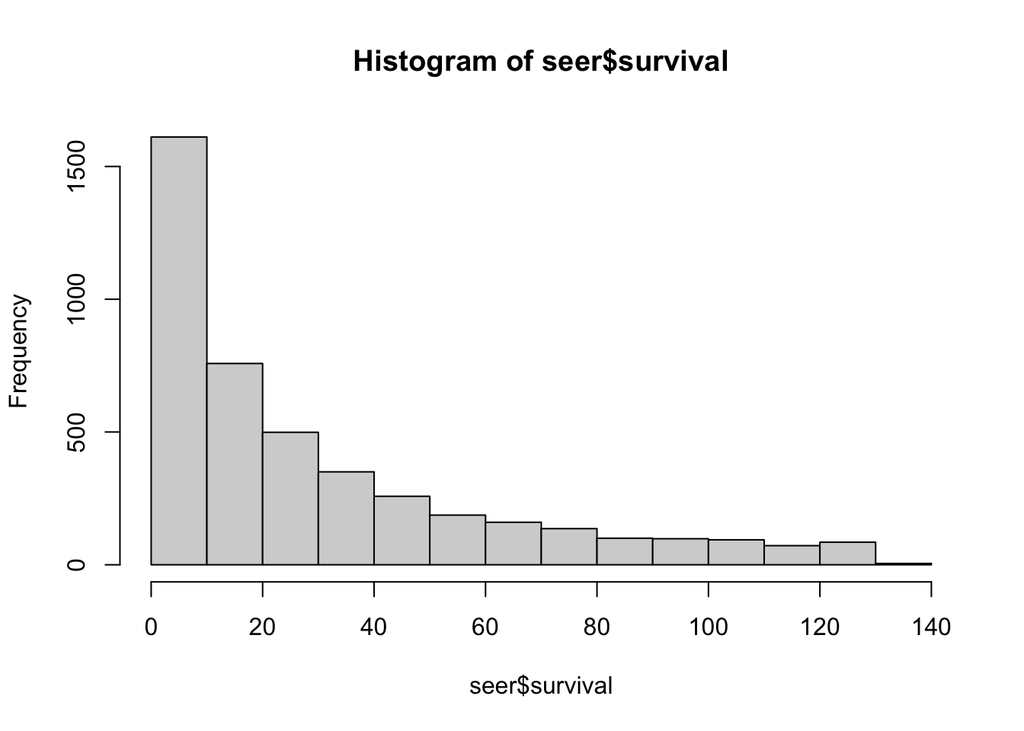

```r
hist(seer$survival)
```

```r
mean(seer$survival == "")
```

```
[1] NA
```

```r
mean(is.na(seer$survival))
```

```
[1] 0.003162412
```

The survival time ranged from 0 to 131 months. These values are all plausible. If a patient died within 1 month of diagnosis, the length of survival would be recorded as 0 months. The distribution of survival time was right skewed with a long right tail and a peak at 0-10 months.

```r
# Check the sex variable
table(seer$sex)
```

```
Female   Male
  2355   2072
```

```r
# Check the stage variable
table(seer$stage)
```

```
         Distant        Localized         Regional Unknown/unstaged
            2922              751              680               74
```

```r
mean(seer$stage == "Unknown/unstaged")
```

```
[1] 0.01671561
```

The observations sum to 4427.

```r
# Check the histology ICD code variable
table(seer$ICD)
```

```
8012 8013 8014 8022 8031 8032 8033 8046 8050 8052 8070 8071 8072 8074 8075 8082
  22   36    1    9    3    3   15  193    1    2  328   30   19    1    1    3
8123 8140 8200 8240 8246 8249 8250 8252 8253 8254 8255 8260 8310 8323 8333 8430
   1 2645   15  404  106   63   34    2   28    4   70   46    3    3    4   43
8480 8481 8490 8507 8550 8560 8574 8575 8576
 112   20   22    6   54   69    3    1    2
```

The observations sum to 4427.

```r
# Check the histology variable
table(seer$histology)
```

```
         Adenocarcinoma    Large Cell Carcinoma Not Otherwise Specified
                   3059                      62                     924
Squamous Cell Carcinoma
                    382
```

The observations sum to 4427.

```r
# Clean the data
# Remove missing survival data
seer <- seer[!is.na(seer$survival), ]

#Filter out "Non-Hispanic Unknown Race"
seer <- seer |>
  filter(race != "Non-Hispanic Unknown Race")
```

## Data Exploration

# Preliminary Results

```r
# Create table summarizing survival time by race/ethnicity

seer <- seer |>
mutate(race = factor(race, levels = c("Non-Hispanic White", "Non-Hispanic Black", "Hispanic (All Races)", "Non-Hispanic Asian or Pacific Islander", "Non-Hispanic American Indian/Alaska Native"))
)

seer$stage <- factor(seer$stage, levels = c("Localized", "Regional", "Distant", "Unknown/unstaged"))

seer$histology <- factor(seer$histology, levels = c("Adenocarcinoma", "Squamous Cell Carcinoma", "Large Cell Carcinoma", "Not Otherwise Specified"))
```

```r
 survival_race <- seer |>
  group_by(seer$race) |>
  summarize(
    N = n(),
    Median = median(survival),
    Minimum = min(survival),
    Maximum = max(survival),
    First_Quartile = quantile(survival, 0.25, na.rm = TRUE),
    Third_Quartile = quantile(survival, 0.75, na.rm = TRUE)
    )
```

```r
survival_race |>
  kbl(
    caption = "Table 1: Survival Time (Months) by Race/Ethnicity",
    col.names = c(
      "Race/Ethnicity",
      "Number of Observations",
      "Median",
      "Min",
      "Max",
      "1st Quartile",
      "3rd Quartile"
      )
    ) |>
  kable_classic(full_width = F, html_font = "Cambria")
```

Table 1: Survival Time (Months) by Race/Ethnicity

| Race/Ethnicity | Number of Observations | Median | Min | Max | 1st Quartile | 3rd Quartile |
| --- | --- | --- | --- | --- | --- | --- |
| Non-Hispanic White | 1719 | 19.0 | 0 | 131 | 6 | 50.00 |
| Non-Hispanic Black | 438 | 11.0 | 0 | 130 | 4 | 29.00 |
| Hispanic (All Races) | 1060 | 18.0 | 0 | 131 | 6 | 41.00 |
| Non-Hispanic Asian or Pacific Islander | 1145 | 19.0 | 0 | 130 | 7 | 43.00 |
| Non-Hispanic American Indian/Alaska Native | 22 | 21.5 | 0 | 82 | 5 | 35.75 |

```r
# Create table of patient characteristics by race/ethnicity

library(gtsummary)
library(gt)

table_demographics <- seer |>
  select(age, sex, stage, histology, race) |>
  tbl_summary(
    by = race,
    label = list(
      age = "Age (Years)",
      sex = "Sex",
      stage = "Cancer Stage at Diagnosis",
      histology = "Histology",
      survival = "Survival Time (Months)"
      )
    ) |>
  modify_caption("Table 2: Patient Characteristics by Race/Ethnicity") |>
  as_gt()

table_demographics
```

Table 2: Patient Characteristics by Race/Ethnicity

| **Characteristic** | **Non-Hispanic White** N = 1,719<sup>1</sup> | **Non-Hispanic Black** N = 438<sup>1</sup> | **Hispanic (All Races)** N = 1,060<sup>1</sup> | **Non-Hispanic Asian or Pacific Islander** N = 1,145<sup>1</sup> | **Non-Hispanic American Indian/Alaska Native** N = 22<sup>1</sup> |
| --- | --- | --- | --- | --- | --- |
| Age (Years) | 46 (42, 49) | 47 (42, 49) | 45 (38, 48) | 46 (41, 49) | 47 (42, 49) |
| Sex |  |  |  |  |  |
| Female | 866 (50%) | 228 (52%) | 608 (57%) | 624 (54%) | 13 (59%) |
| Male | 853 (50%) | 210 (48%) | 452 (43%) | 521 (46%) | 9 (41%) |
| Cancer Stage at Diagnosis |  |  |  |  |  |
| Localized | 350 (20%) | 64 (15%) | 202 (19%) | 127 (11%) | 2 (9.1%) |
| Regional | 316 (18%) | 79 (18%) | 143 (13%) | 129 (11%) | 6 (27%) |
| Distant | 1,036 (60%) | 289 (66%) | 693 (65%) | 868 (76%) | 14 (64%) |
| Unknown/unstaged | 17 (1.0%) | 6 (1.4%) | 22 (2.1%) | 21 (1.8%) | 0 (0%) |
| Histology |  |  |  |  |  |
| Adenocarcinoma | 1,062 (62%) | 282 (64%) | 716 (68%) | 956 (83%) | 16 (73%) |
| Squamous Cell Carcinoma | 196 (11%) | 43 (9.8%) | 69 (6.5%) | 64 (5.6%) | 4 (18%) |
| Large Cell Carcinoma | 27 (1.6%) | 13 (3.0%) | 10 (0.9%) | 11 (1.0%) | 0 (0%) |
| Not Otherwise Specified | 434 (25%) | 100 (23%) | 265 (25%) | 114 (10.0%) | 2 (9.1%) |

<sup>1</sup> Median (Q1, Q3); n (%)

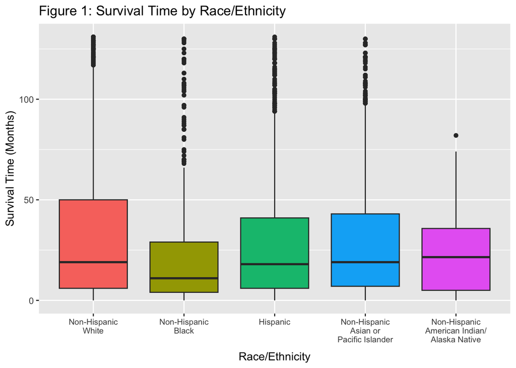

```r
# Create boxplot of survival time by race/ethnicity

race_xaxis <- c(
  "Non-Hispanic White" = "Non-Hispanic\nWhite",
  "Non-Hispanic Black" = "Non-Hispanic\nBlack",
  "Hispanic (All Races)" = "Hispanic",
  "Non-Hispanic Asian or Pacific Islander" = "Non-Hispanic\nAsian or\nPacific Islander",
  "Non-Hispanic American Indian/Alaska Native" = "Non-Hispanic\nAmerican Indian/\nAlaska Native"
)

seer |>
  ggplot() +
  geom_boxplot(mapping = aes(x = race, y = survival, fill = race)) +
  labs(title = "Figure 1: Survival Time by Race/Ethnicity",
       x = "Race/Ethnicity",
       y = "Survival Time (Months)",
       fill = "Race/Ethnicity") +
  scale_x_discrete(labels = race_xaxis) +
  theme(axis.text.x = element_text (size = 8),
        legend.position = "none",
        axis.title.x = element_text(margin = margin(t = 8)))
```

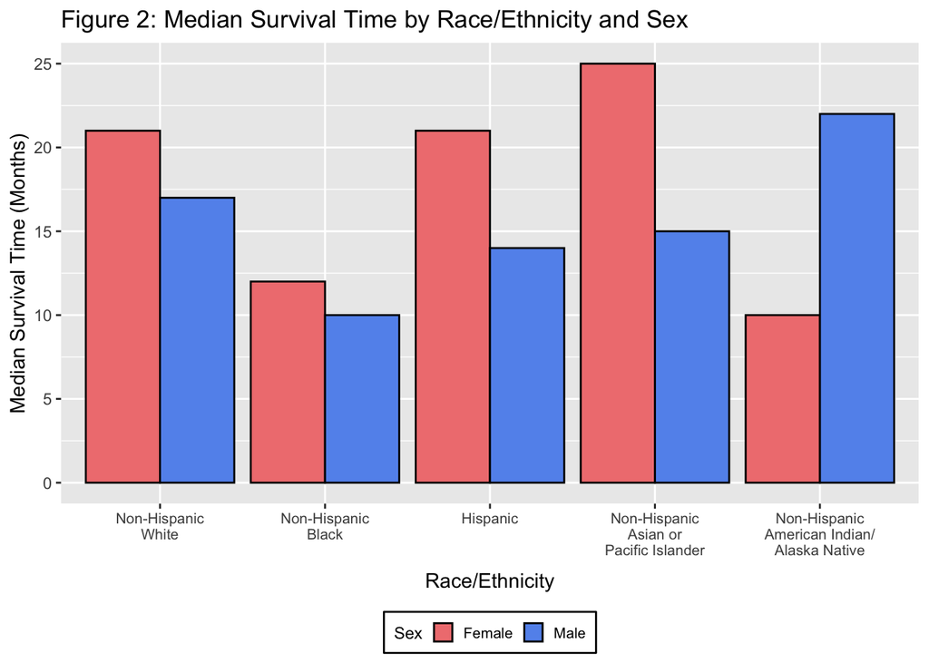

```r
# Create barchart of median survival time by race/ethnicity and sex

survival_race_sex <- seer |>

  group_by(race, sex) |>
  summarize(med_survival = median(survival))
survival_race_sex |>
  ggplot() +
  geom_bar(mapping = aes(x = race, y = med_survival, fill = sex),
           stat = "identity",
           position = position_dodge2(preserve = "single", padding = 0),
           color = "black") +
  labs(title = "Figure 2: Median Survival Time by Race/Ethnicity and Sex",
       x = "Race/Ethnicity",
       y = "Median Survival Time (Months)",
       fill = "Sex") +
  scale_fill_manual(values = c("Male" = "cornflowerblue", "Female" = "lightcoral")) +
  scale_x_discrete(labels = race_xaxis) +
  theme(axis.text.x = element_text (size = 8),
        axis.title.x = element_text(margin = margin(t = 8)),
        legend.position = "bottom",
        legend.background = element_rect(color = "black", fill = NA),
        legend.text = element_text(size = 8),
        legend.title = element_text(size = 9),
        legend.key.size = unit(0.4, "cm"))
```

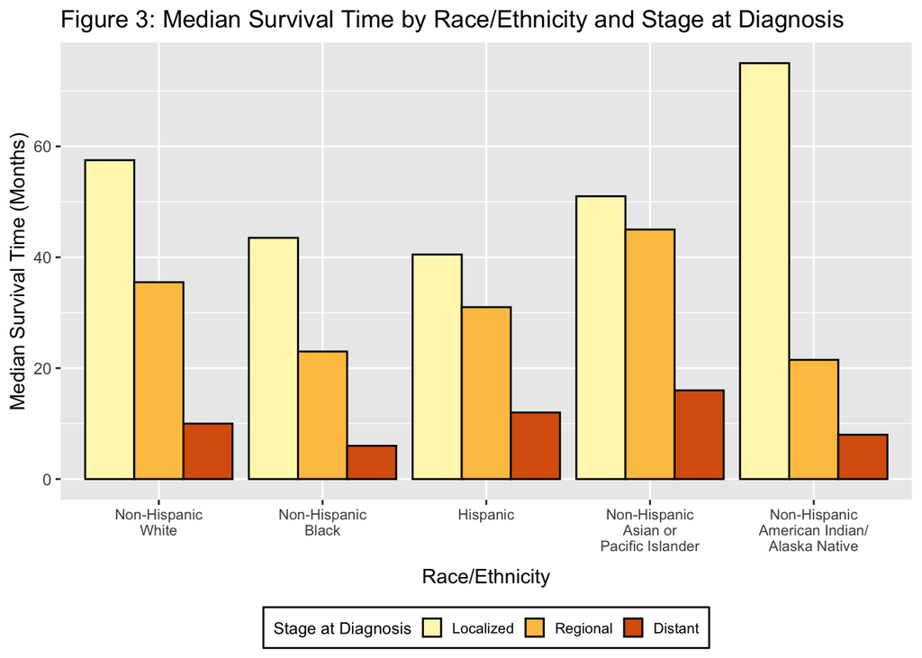

```r
# Create barchart of median survival time by race/ethnicity and stage at diagnosis, excluding individuals who were labeled as "Unknown/unstaged".

survival_race_stage <- seer |>
  filter(stage != "Unknown/unstaged") |>
  group_by(race, stage) |>
  summarize(med_survival = median(survival))
survival_race_stage |>
  ggplot() +
  geom_bar(mapping = aes(x = race, y = med_survival, fill = stage),
           stat = "identity",
           position = position_dodge2(preserve = "single", padding = 0),
           color = "black") +
  scale_fill_brewer(palette = "YlOrBr") +
  labs(title = "Figure 3: Median Survival Time by Race/Ethnicity and Stage at Diagnosis",
       x = "Race/Ethnicity",
       y = "Median Survival Time (Months)",
       fill = "Stage at Diagnosis") +
   scale_x_discrete(labels = race_xaxis) +
  theme(axis.text.x = element_text (size = 8),
        axis.title.x = element_text(margin = margin(t = 8)),
        legend.position = "bottom",
        legend.background = element_rect(color = "black", fill = NA),
        legend.text = element_text(size = 8),
        legend.title = element_text(size = 9),
        legend.key.size = unit(0.4, "cm"))
```

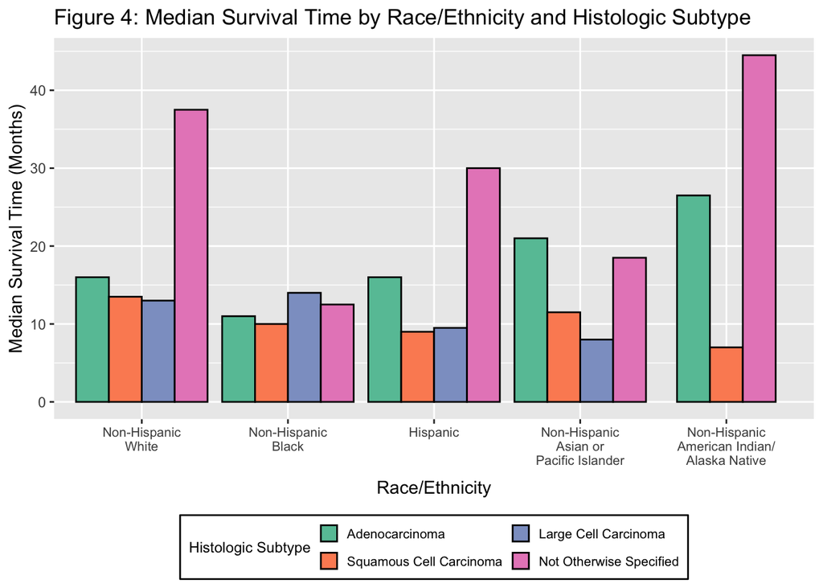

```r
# Create barchart of median survival time by race/ethnicity and stage at diagnosis

survival_race_hist <- seer |>
  group_by(race, histology) |>
  summarize(med_survival = median(survival))
survival_race_hist |>
  ggplot() +
  geom_bar(mapping = aes(x = race, y = med_survival, fill = histology),
           stat = "identity",
           position = position_dodge2(preserve = "single", padding = 0),
           color = "black") +
  scale_fill_brewer(palette = "Set2") +
  labs(title = "Figure 4: Median Survival Time by Race/Ethnicity and Histologic Subtype",
       x = "Race/Ethnicity",
       y = "Median Survival Time (Months)",
       fill = "Histologic Subtype") +
  scale_x_discrete(labels = race_xaxis) +
  theme(axis.text.x = element_text (size = 8),
        axis.title.x = element_text(margin = margin(t = 8)),
        legend.position = "bottom",
        legend.background = element_rect(color = "black", fill = NA),
        legend.text = element_text(size = 8),
        legend.title = element_text(size = 9),
        legend.key.size = unit(0.4, "cm")) +
  guides(fill = guide_legend(nrow = 2))
```

# Conclusion

In this population of California residents aged 18 to 50 years with first-primary, non-small cell lung cancer (n = 4384), it appears that median survival time is associated with race/ethnicity. The median survival time was lowest for the NHB group (11.0 months) and highest for the NHAIAN group (21.5 months). The median survival time was similar for the NHW (19 months), Hispanic (18 months), and NHAPI (19 months) groups. The small sample size of the NHAIAN group (n = 22) limits the ability to draw definitive conclusions about this group.

The NHB group had a lower percentage of patients diagnosed with localized cancer (15%) compared to the NHW (20%) and Hispanic (19%) groups, which may have contributed to the lower median survival time. However, NHAPI had a lower percentage of patients diagnosed with localized cancer (11%) compared to the NHB group (15%) despite having a higher median survival time. When stratifying by race/ethnicity and stage at diagnosis, there still remained differences in medial survival across racial/ethnic groups among those with the same stage at diagnosis (Fig. 3). Differences in the distribution of cancer stage may contribute to differences in the median survival time across the racial/ethnic groups but do not fully explain the differences.

References:  
1. American Cancer Society. Lung Cancer Statistics. American Cancer Society. Updated January 29, 2024. Accessed October 27, 2024. https://www.cancer.org/cancer/types/lung-cancer/about/key-statistics.html  
2. Howlader N, Noone AM, Krapcho M, et al. SEER Cancer Statistics Review 1975-2018. Published April 15, 2021. Accessed October 27, 2024. https://seer.cancer.gov/archive/csr/1975_2018/results_merged/sect_01_overview.pdf  
3. Thomas A, Chen Y, Yu T, Jakopovic M, Giaccone G. Trends and Characteristics of Young Non-Small Cell Lung Cancer Patients in the United States. Front Oncol. 2015;5:113.  
4. Suidan AM, Roisman L, Belilovski Rozenblum A, et al. Lung Cancer in Young Patients: Higher Rate of Driver Mutations and Brain Involvement, but Better Survival. J Glob Oncol. 2019;5:1-8.  
5. Ellis L, Canchola AJ, Spiegel D, Ladabaum U, Haile R, Gomez SL. Racial and Ethnic Disparities in Cancer Survival: The Contribution of Tumor, Sociodemographic, Institutional, and Neighborhood Characteristics. J Clin Oncol. 2018;36(1):25-33.  
6. Surveillance, Epidemiology, and End Results (SEER) Program, National Cancer Institute. SEER*Stat Database: Incidence - SEER Research Data, 17 Registries (excl AK), Nov 2023 Sub (2000-2021). National Cancer Institute, DCCPS, Surveillance Research Program. Released April 2024. Accessed October 17, 2024.  
7. Hansen RN, Zhang Y, Seal B, et al. Long-term survival trends in patients with unresectable stage III non-small cell lung cancer receiving chemotherapy and radiation therapy: a SEER cancer registry analysis. BMC Cancer. 2020;20(1):276.  
8. Ganti AK, Klein AB, Cotarla I, Seal B, Chou E. Update of Incidence, Prevalence, Survival, and Initial Treatment in Patients With Non-Small Cell Lung Cancer in the US. JAMA Oncol. 2021;7(12):1824-32.